# Modelo VAR aplicado a la economía de México

José Julián Mateo López

2022-15-9

## Introducción

Una de las principales funciones hoy en día de los economistas es poder contrastar o evaluar el gran numero de políticas económicas aplicadas por parte de las autoridades gubernamentales, con el objetivo de contribuir a la mejora económica del país. Los amantes de la econometría saben perfectamente que existe un sin numero de modelos econométricos que se podrían llevar a cabo para le evaluación de políticas públicas. Uno de ellos es la metodología de vectores autorregresivos, planteado por Sims en 1980 y 1986. Los modelos vectores autorregresivos durante los últimos años han alcanzo una gran popularidad en el análisis empírico para las series de tiempo económicas debido a su gran utilidad en análisis de este tipo.

Los modelos VAR son modelos econométricos multivariados, es decir, no son mas que la extensión de los modelos autorregresivos univariados. Uno de los principales beneficios de trabajar con este tipo de modelos es que son modelos ateóricos, es decir, no se necesita de una teoría económica previa para poder plantearlos. Este tipo de modelo de series de tiempo se caracteriza por querer explicar un conjunto de variables endógenas. A primera vista, la metodología VAR se asemeja a los modelos de ecuaciones simultaneas, pues considera diversas variables endógenas de manera conjunta. Sin embargo, en los modelos VAR cada variable endógena de explica por sus propios rezagos, o pasados, y por los valores rezagados de todas las demás variables endógenas del modelo. Usualmente no hay variables endógenas, tal como ocurre en los modelos de ecuaciones simultaneas. Este trabajo constituye un ejercicio sencillo de la econometría aplicada.

## Obtención de la información

La base de datos con la que se va a trabajar fue construida con datos del INEGI y Banxico. Como de costumbre, para poder manipular y analizar nuestras observaciones necesitamos importar nuestra base de datos, tal como se muestra en el siguiente comando. El nombre del objeto es “datos” que será utilizado para la estimación del modelo VAR.

```r
library(readxl)
datos <- read_excel("varinfla.xls")
attach(datos)
head(datos)
```

| M2 | INPC |
| --- | --- |
| 28.7740 | 59.8083 |
| 29.3109 | 60.3388 |
| 29.8290 | 60.6734 |
| 30.1613 | 61.0186 |
| 30.4289 | 61.2467 |
| 30.9230 | 61.6095 |

Con la función `head()` podemos visualizar las primer observaciones de las series, que están dadas en miles de pesos con una frecuencia mensual. Por su parte, la función `attach()`, nos da la posibilidad de anclar las variables en el área de trabajo, de forma que el lenguaje las pueda leer. Una vez importada la base de datos, procedemos a darle un formato de series de tiempo, para posteriormente convertirlas en logaritmos, por cuestiones metodológicas y practicas. Para lograr ello, necesitamos activar la libraría **tseries**, primero transformamos el indice de precios, posteriormente la base monetaria M2.

```r
library(tseries)
INPC_ts <- ts(INPC, start = 2000, frequency = 12)
M2_ts <- ts(M2,start = 2000, frequency = 12)
#Transformamos las series en términos logarítmicos
logINPC <- log(INPC_ts)
logM2 <- log(M2_ts)
```

Con la siguiente linea de código se puede apreciar la visualización gráfica de las series con datos transformados.

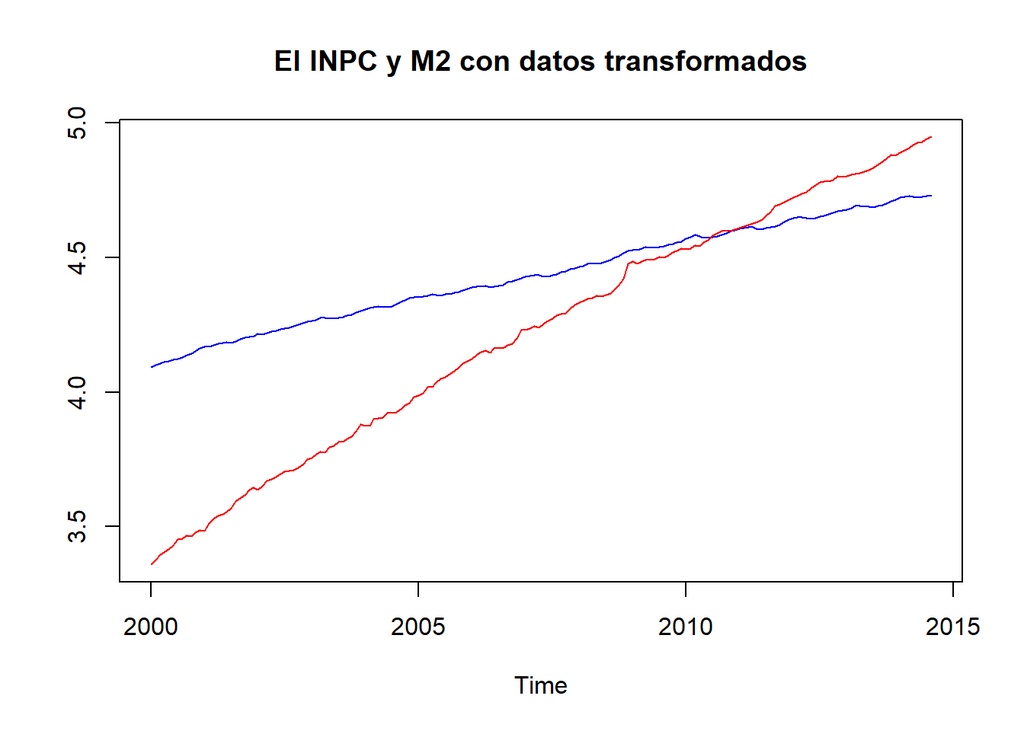

```r
library(stats)
ts.plot(logINPC,logM2, col = c("blue","red"), main = "El INPC y M2 con datos transformados")
```

## Estacionariedad de las series

Una de las condiciones para trabajar con modelos de series de tiempo es que las series deben cumplir la propiedad estadística de ser de ruido blanco, es decir, deben ser estacionarias. Una serie es estacionaria cuando su media y varianza son constantes durante el tiempo, o sea, son invariantes el tiempo. Cuando una serie presenta al menos una raíz unitaria se dice que es una serie de caminata aleatoria, por el contrario, cuando no presenta raíz unitaria es un proceso estocástico puramente aleatorio de ruido blanco. Detrás de este concepto básico en econometría de series de tiempo existe una amplia conceptualización matemática, no obstante, en este documento nos limitaremos a únicamente realizar las pruebas pertinentes para corroborar la estacionariedad de las series y de ser el caso, aplicar las técnicas necesarias para transformar las series a un proceso de ruido blanco.

Una primer aproximación para determinar la estacionariedad de las series es el análisis gráfico. Como se pudo apreciar en el gráfico anterior del logaritmos de las series, estas parecen presentar tendencia o una trayectoria determinista, por lo que, podemos asumir que tanto el indice de precios como la base monetaria son no estacionarias. Recurriendo a pruebas estadísticas mas formales, a continuación se presenta la prueba de Dickey Fuller aumentada, misma que el propio lenguaje R nos da la oportunidad de aplicar con gran facilidad. Para realizar la prueba de raíz unitaria de Dickey Fuller Aumentada (ADF) activamos la librería **Urca**. A continuación se contrasta la estacionariedad del indice de precios.

```r
library(urca)
summary(ur.df(logINPC, type = "none", selectlags = "AIC"))
```

```
##
## ###############################################
## # Augmented Dickey-Fuller Test Unit Root Test #
## ###############################################
##
## Test regression none
##
##
## Call:
## lm(formula = z.diff ~ z.lag.1 - 1 + z.diff.lag)
##
## Residuals:
##        Min         1Q     Median         3Q        Max
## -0.0093954 -0.0015285  0.0003127  0.0018731  0.0069307
##
## Coefficients:
##             Estimate Std. Error t value Pr(>|t|)
## z.lag.1    4.405e-04  7.598e-05   5.798 3.14e-08 ***
## z.diff.lag 4.532e-01  6.741e-02   6.724 2.51e-10 ***
## ---
## Signif. codes:  0 '***' 0.001 '**' 0.01 '*' 0.05 '.' 0.1 ' ' 1
##
## Residual standard error: 0.003061 on 172 degrees of freedom
## Multiple R-squared:  0.6247, Adjusted R-squared:  0.6204
## F-statistic: 143.2 on 2 and 172 DF,  p-value: < 2.2e-16
##
##
## Value of test-statistic is: 5.798
##
## Critical values for test statistics:
##       1pct  5pct 10pct
## tau1 -2.58 -1.95 -1.62
```

Para contrastar lo anterior, planteamos como hipótesis nula:

Ho: La serie presenta raíz unitaria

Ha: La serie no presenta raíz unitaria

Ahora, procedemos a aplicar la prueba de estacionaridad Dickey-Fuller-Aumentada a la base monetaria M2, misma que se muestra a continuación.

```r
library(urca)
summary(ur.df(logM2, type = "none", selectlags = "AIC"))
```

```
##
## ###############################################
## # Augmented Dickey-Fuller Test Unit Root Test #
## ###############################################
##
## Test regression none
##
##
## Call:
## lm(formula = z.diff ~ z.lag.1 - 1 + z.diff.lag)
##
## Residuals:
##       Min        1Q    Median        3Q       Max
## -0.017502 -0.004469 -0.000487  0.004232  0.046229
##
## Coefficients:
##             Estimate Std. Error t value Pr(>|t|)
## z.lag.1    0.0018928  0.0002163   8.750 1.91e-15 ***
## z.diff.lag 0.0896482  0.0756871   1.184    0.238
## ---
## Signif. codes:  0 '***' 0.001 '**' 0.01 '*' 0.05 '.' 0.1 ' ' 1
##
## Residual standard error: 0.008239 on 172 degrees of freedom
## Multiple R-squared:  0.5394, Adjusted R-squared:  0.534
## F-statistic: 100.7 on 2 and 172 DF,  p-value: < 2.2e-16
##
##
## Value of test-statistic is: 8.7504
##
## Critical values for test statistics:
##       1pct  5pct 10pct
## tau1 -2.58 -1.95 -1.62
```

Una vez identificado que ambas series no son estacionarias, tenemos que diferenciarlas d veces de forman que se puedan obtener series puramente aleatorias de ruido blanco. Eso resulta una tarea muy fácil con el lenguaje R, debido a su potencia estadística. Como primer paso, con la función `ndiffs()` podemos identificar cuantas diferencias necesita la serie para convertirla en estacionaria.

```r
# Determinar el numero de diferencias del indice de precios
library(forecast)
ndiffs(logINPC)
```

```
## [1] 1
```

```r
#Determinar el numero de diferencias del indice de la base monetaria
ndiffs(logM2)
```

```
## [1] 2
```

Al parecer la serie del indice de precios es estacionaria en sus primeras diferencias, por el contrario, el indice de la base monetaria es estacionario en sus segunda diferencias, por lo que, procederemos a hacer ambas diferencias de las dos series para no haya un desbalance en el tratamiento econométrico.En ese sentido, procedemos a diferenciarlas a través de la función `diff`.

```r
#Primeras diferencias del logINPC
dlogINPC <- diff(logINPC)
#Segundas diferencias del INPC
d2logINPC <- diff(dlogINPC)
#Primeras diferencias del logaritmo de la base monetaria M2
dlogM2 <- diff(logM2)
#Segundas diferencias del logM2
d2logM2 <- diff(dlogM2)
```

En el gráfico de la parte inferior de puede apreciar procesos aleatorios puramente aleatorios de ruido blanco. Es decir, se han obtenido las segundas diferencias de ambas series con el objeto de tener mejores resultados. Por consiguiente, hemos transformados las series de forma que estas presenta media y varianza constante en el tiempo. Ampliamente se puede ver la diferencia con el gráfico anterior, donde las series mantenían esa tendencia estocástica.

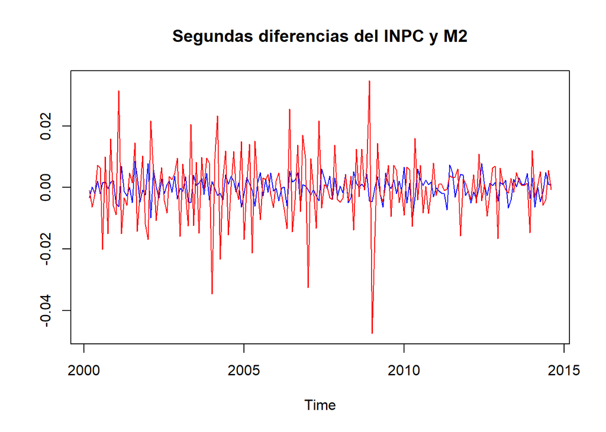

```r
ts.plot(d2logINPC, d2logM2, col = c("Blue","red"), main = "Segundas diferencias del INPC y M2")
```

## Causalidad de Granger

A continuación se llevara a cabo la prueba de causalidad de Granger para determinar el orden causal entre las series. Para poder realizar este tes, primero es necesario activar la librería **lmtes**, una vez activada planteamos la hipótesis nula a contrastar, misma que se plantea a continuación.

Ho: La oferta de dinero M2 no causa en el sentido de Granger al indice de precios, > 0.05.

Ha: La oferta de dinero M2 causa en el sentido de Granger al indice de precios: < 0.05.

Ahora procedemos a la aplicación de la prueba de causalidad de Granger.

```r
library(lmtest)
grangertest(d2logINPC ~ d2logM2, order = 1)
```

|  | Res.Df | Df | F | Pr(>F) |
| --- | --- | --- | --- | --- |
| 1 | 170 | NA | NA | NA |
| 2 | 171 | -1 | 0.8795894 | 0.3496447 |

Ho: Los precios no causan en el sentido de Granger a la oferta monetaria M2, > 0.05

Ha: Los precios causan en el sentido de Granger la oferta monetaria M2, < 0.05

```r
grangertest(d2logM2 ~ d2logINPC, order = 1)
```

|  | Res.Df | Df | F | Pr(>F) |
| --- | --- | --- | --- | --- |
| 1 | 170 | NA | NA | NA |
| 2 | 171 | -1 | 0.09088673 | 0.7634213 |

Puesto que el P-value recoge el valor de 0.76, se confirma que los precios no causan a la oferta monetaria, al menos evaluada con un rezago. En este tipo de contraste resulta necesario llevar a cabo diversas aplicaciones para verificar la causalidad de la series, entonces, a continuación se presenta la prueba en varios rezagos.

```r
grangertest(d2logM2 ~ d2logINPC, order = 12)
```

|  | Res.Df | Df | F | Pr(>F) |
| --- | --- | --- | --- | --- |
| 1 | 137 | NA | NA | NA |
| 2 | 149 | -12 | 1.012433 | 0.4409769 |

se ha verificado que hasta el rezago 12, se continua aceptando la hipótesis nula, es decir, los precios no causan en el sentido de Granger a la base monetaria M2. En conclusión, la causalidad va de la oferta monetaria hacia el indice de precios. Lo cual, tiene todo el sentido económico.

## ANÁLISIS ECONOMÉTRICO: APLICACIÓN DEL MODELO

Una vez realiza las transformaciones necesarias para poder trabajar con un modelo de este tipo, procedemos al análisis econométrico, es decir, la aplicación del modelo. Como primer paso, debemos descargar y activar la paquetería **vars**, misma que nos va a ayudar a llevar a cabo todas las implicancias relacionadas al modelo. No obstante, como paso previo a la identificación de los rezagos del modelo, es necesario crear un objeto de trabajo que contenga las variables transformadas y estacionarias. También resulta pertinente dar formato de series de tiempo a los objetos, siguiendo los pasos iniciales de este documento.

```r
vard2logINPC <- ts(d2logINPC, start = 2001, frequency = 12)
vard2logM2 <- ts(d2logM2, start = 2001, frequency = 12)
ejevar <- ts(cbind(vard2logINPC, vard2logM2))
```

Ahora, como siguiente paso es identificar el orden del VAR a través de los criterios de información: Akaike (AIC),Hanna-Quin (HQ), Schwarz (SC), y Error de Predicción Final (FPE), para ello se utiliza el siguiente comando de código.

```r
library(vars)
VARselect(ejevar, lag.max = 12)
```

```
## $selection
## AIC(n)  HQ(n)  SC(n) FPE(n)
##     11     11      2     11
##
## $criteria
##                    1             2             3             4             5
## AIC(n) -2.046463e+01 -2.068196e+01 -2.065764e+01 -2.075149e+01 -2.075348e+01
## HQ(n)  -2.041820e+01 -2.060458e+01 -2.054931e+01 -2.061220e+01 -2.058323e+01
## SC(n)  -2.035027e+01 -2.049137e+01 -2.039081e+01 -2.040842e+01 -2.033417e+01
## FPE(n)  1.295173e-09  1.042211e-09  1.067940e-09  9.723977e-10  9.706467e-10
##                    6             7             8             9            10
## AIC(n) -2.090388e+01 -2.097478e+01 -2.104458e+01 -2.103653e+01 -2.109132e+01
## HQ(n)  -2.070268e+01 -2.074263e+01 -2.078147e+01 -2.074247e+01 -2.076631e+01
## SC(n)  -2.040834e+01 -2.040300e+01 -2.039656e+01 -2.031228e+01 -2.029083e+01
## FPE(n)  8.353390e-10  7.784502e-10  7.263246e-10  7.326459e-10  6.941160e-10
##                   11            12
## AIC(n) -2.130916e+01 -2.130390e+01
## HQ(n)  -2.095320e+01 -2.091699e+01
## SC(n)  -2.043244e+01 -2.035094e+01
## FPE(n)  5.587598e-10  5.623294e-10
```

Para identificar el orden del VAR, en esta aplicación se utilizaron en el criterio de **lag.max** como máximo 12 rezagos, que es lo recomendable en este tipo de modelos. Ahora, de acuerdo a los resultados de los criterios de información, el orden del VAR debe de ser de 11 rezagos para la estimación de los coeficientes parciales del modelo. Es decir, tendremos 2 ecuaciones con 11 rezagos cada una de sus propios valores pasados.

Una vez identificado el orden del modelo, se procede a la estimación del mismo. En la siguiente linea de código se puede apreciar el proceso para la estimación del modelo VAR de orden 11 o bien VAR(11). Guardamos nuestra regresión en la variable denominada “var1”.

```r
var1 <- VAR(ejevar, p = 11)
var1
```

```
##
## VAR Estimation Results:
## =======================
##
## Estimated coefficients for equation vard2logINPC:
## =================================================
## Call:
## vard2logINPC = vard2logINPC.l1 + vard2logM2.l1 + vard2logINPC.l2 + vard2logM2.l2 + vard2logINPC.l3 + vard2logM2.l3 + vard2logINPC.l4 + vard2logM2.l4 + vard2logINPC.l5 + vard2logM2.l5 + vard2logINPC.l6 + vard2logM2.l6 + vard2logINPC.l7 + vard2logM2.l7 + vard2logINPC.l8 + vard2logM2.l8 + vard2logIN…
##
##  vard2logINPC.l1    vard2logM2.l1  vard2logINPC.l2    vard2logM2.l2
##    -0.5768876559    -0.0153916910    -0.6496239677     0.0225320104
##  vard2logINPC.l3    vard2logM2.l3  vard2logINPC.l4    vard2logM2.l4
##    -0.6720339066     0.0258940415    -0.6540235497     0.0795080689
##  vard2logINPC.l5    vard2logM2.l5  vard2logINPC.l6    vard2logM2.l6
##    -0.5936082236     0.0019055836    -0.7731697569     0.0257630905
##  vard2logINPC.l7    vard2logM2.l7  vard2logINPC.l8    vard2logM2.l8
##    -0.6635451262    -0.0057925819    -0.6685684171    -0.0051972985
##  vard2logINPC.l9    vard2logM2.l9 vard2logINPC.l10   vard2logM2.l10
##    -0.5278806069     0.0220922428    -0.4810434376     0.0046915004
## vard2logINPC.l11   vard2logM2.l11            const
##    -0.4276815925     0.0081195814    -0.0001442569
##
##
## Estimated coefficients for equation vard2logM2:
## ===============================================
## Call:
## vard2logM2 = vard2logINPC.l1 + vard2logM2.l1 + vard2logINPC.l2 + vard2logM2.l2 + vard2logINPC.l3 + vard2logM2.l3 + vard2logINPC.l4 + vard2logM2.l4 + vard2logINPC.l5 + vard2logM2.l5 + vard2logINPC.l6 + vard2logM2.l6 + vard2logINPC.l7 + vard2logM2.l7 + vard2logINPC.l8 + vard2logM2.l8 + vard2logINPC…
##
##  vard2logINPC.l1    vard2logM2.l1  vard2logINPC.l2    vard2logM2.l2
##    -1.714432e-01    -7.629557e-01     1.109554e-01    -8.434147e-01
##  vard2logINPC.l3    vard2logM2.l3  vard2logINPC.l4    vard2logM2.l4
##    -6.402061e-03    -6.063436e-01    -6.657233e-02    -6.978840e-01
##  vard2logINPC.l5    vard2logM2.l5  vard2logINPC.l6    vard2logM2.l6
##    -1.467567e-01    -6.033920e-01     1.071395e-01    -5.911775e-01
##  vard2logINPC.l7    vard2logM2.l7  vard2logINPC.l8    vard2logM2.l8
##    -5.209120e-01    -4.820850e-01     5.843583e-02    -4.042083e-01
##  vard2logINPC.l9    vard2logM2.l9 vard2logINPC.l10   vard2logM2.l10
##    -2.264201e-01    -2.957712e-01    -3.519280e-01    -2.607288e-01
## vard2logINPC.l11   vard2logM2.l11            const
##    -4.569036e-02    -1.952368e-01    -1.772883e-05
```

En la estimación anterior se pueden observar ambas ecuaciones, tanto la ecuación para el indice de precios como la ecuación de la base monetaria, así como los coeficientes parciales evaluados en 11 rezagos.

Como toda metología econométrica, los modelos estimados deben ser sometidos a pruebas de especificación. Una de las propiedades que plantea el modelo VAR es que debe cumplir la condición de estabilidad, misma que se puede corroborar con los polinomios caracteristicos. Para poder acceder a estos polinomios, hacemos uso de la función `summary()`, y le indicamos como parametro el modelo estimado. Tal como se muestra en el comando siguiente.

```r
summary(var1)
```

```
##
## VAR Estimation Results:
## =========================
## Endogenous variables: vard2logINPC, vard2logM2
## Deterministic variables: const
## Sample size: 163
## Log Likelihood: 1316.416
## Roots of the characteristic polynomial:
## 0.9851 0.9851 0.9604 0.9604 0.9425 0.9425 0.9343 0.9343 0.906 0.906 0.8852 0.8852 0.8749 0.8749 0.8717 0.8717 0.8679 0.8553 0.8553 0.8127 0.8127 0.7702
## Call:
## VAR(y = ejevar, p = 11)
##
##
## Estimation results for equation vard2logINPC:
## =============================================
## vard2logINPC = vard2logINPC.l1 + vard2logM2.l1 + vard2logINPC.l2 + vard2logM2.l2 + vard2logINPC.l3 + vard2logM2.l3 + vard2logINPC.l4 + vard2logM2.l4 + vard2logINPC.l5 + vard2logM2.l5 + vard2logINPC.l6 + vard2logM2.l6 + vard2logINPC.l7 + vard2logM2.l7 + vard2logINPC.l8 + vard2logM2.l8 + vard2logIN…
##
##                    Estimate Std. Error t value Pr(>|t|)
## vard2logINPC.l1  -0.5768877  0.0755409  -7.637 3.16e-12 ***
## vard2logM2.l1    -0.0153917  0.0265236  -0.580   0.5626
## vard2logINPC.l2  -0.6496240  0.0811166  -8.009 4.05e-13 ***
## vard2logM2.l2     0.0225320  0.0324482   0.694   0.4886
## vard2logINPC.l3  -0.6720339  0.0866516  -7.756 1.65e-12 ***
## vard2logM2.l3     0.0258940  0.0389673   0.665   0.5075
## vard2logINPC.l4  -0.6540235  0.0882744  -7.409 1.09e-11 ***
## vard2logM2.l4     0.0795081  0.0403071   1.973   0.0505 .
## vard2logINPC.l5  -0.5936082  0.0888574  -6.680 5.19e-10 ***
## vard2logM2.l5     0.0019056  0.0429004   0.044   0.9646
## vard2logINPC.l6  -0.7731698  0.0783469  -9.869  < 2e-16 ***
## vard2logM2.l6     0.0257631  0.0421322   0.611   0.5419
## vard2logINPC.l7  -0.6635451  0.0897558  -7.393 1.19e-11 ***
## vard2logM2.l7    -0.0057926  0.0421757  -0.137   0.8910
## vard2logINPC.l8  -0.6685684  0.0891632  -7.498 6.74e-12 ***
## vard2logM2.l8    -0.0051973  0.0404152  -0.129   0.8979
## vard2logINPC.l9  -0.5278806  0.0875485  -6.030 1.39e-08 ***
## vard2logM2.l9     0.0220922  0.0386188   0.572   0.5682
## vard2logINPC.l10 -0.4810434  0.0814811  -5.904 2.56e-08 ***
## vard2logM2.l10    0.0046915  0.0323905   0.145   0.8850
## vard2logINPC.l11 -0.4276816  0.0759902  -5.628 9.59e-08 ***
## vard2logM2.l11    0.0081196  0.0258292   0.314   0.7537
```

[output cut: 42 more lines]

```
## Residual standard error: 0.008133 on 140 degrees of freedom
## Multiple R-Squared: 0.5428,  Adjusted R-squared: 0.4709
## F-statistic: 7.555 on 22 and 140 DF,  p-value: 6.685e-15
##
##
##
## Covariance matrix of residuals:
##              vard2logINPC vard2logM2
## vard2logINPC    6.798e-06  7.967e-07
## vard2logM2      7.967e-07  6.615e-05
##
## Correlation matrix of residuals:
##              vard2logINPC vard2logM2
## vard2logINPC      1.00000    0.03757
## vard2logM2        0.03757    1.00000
```

Como se habrá dado cuenta el lector, la función `summary()` nos desglosa los coeficientes estimados así como los estadísticos necesarios para llevar a cabo la inferencia estadística. Las dos ecuaciones de regresión anterior especifican los estadísticos principales que generalmente se obtienen en un modelo clásico de regresión lineal, se puede apreciar la signicancia individual y global de ambas ecuaciones, así como la bondad de ajuste de cada ecuación correspondiente. Para evaluar, la propiedad de estabilidad se necesita verificar que los polinomios característicos estimados sean menor a 1. Efectivamente, como se puede observar los 22 polinomios estimados son menores a la unida, es decir, que efectivamente en este ejercicio tenemos el numero correcto de rezagos y que el orden de nuestro modelo VAR específicamente si es 11. En ese sentido, podemos afirmar que el modelo **var1** satisface la condición de estabilidad.

Una vez estimado el sistema de ecuaciones del modelo VAR, podemos acceder a la visualización gráfica de la variable observada versus la variable estimada, así como también de los residuos a través de la función `plot()`.

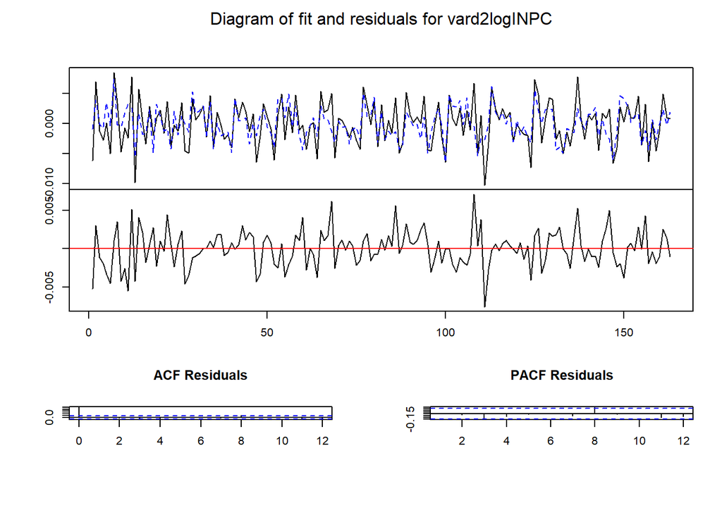

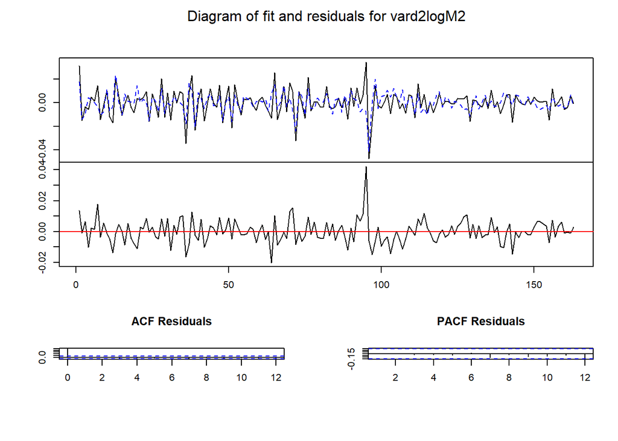

```r
plot(var1)
```

## PRUEBAS DE ESPECIFICACIÓN

Ahora nos encargaremos de llevar a cabo la metodología básica para contrastar el comportamiento estadístico de los residuales. De la misma forma como lo plantea el modelo clásico de regresión lineal, en este tipos de modelos, los residuos de la estimación deben distribuirse como una normal, con media 0. Por consiguiente, el código siguiente muestra el proceso para la aplicación de este test. R es un lenguaje estadístico que nos permite realizar estas pruebas de una manera sencilla y rápida.

```r
normalidad <- normality.test(var1)
normalidad$jb.mul
```

```
## $JB
##
##  JB-Test (multivariate)
##
## data:  Residuals of VAR object var1
## Chi-squared = 199.18, df = 4, p-value < 2.2e-16
##
##
## $Skewness
##
##  Skewness only (multivariate)
##
## data:  Residuals of VAR object var1
## Chi-squared = 25.49, df = 2, p-value = 2.917e-06
##
##
## $Kurtosis
##
##  Kurtosis only (multivariate)
##
## data:  Residuals of VAR object var1
## Chi-squared = 173.69, df = 2, p-value < 2.2e-16
```

Para verificar la normalidad de los residuos se aplica la prueba Jarque-Bera multivariada, donde la regla de decisión es que si la probabilidad asociada a este estadístico tanto de la kurtosis como el del sesgo, son < 0.05, se rechaza la hipótesis nula de normalidad de los residuales. El p-value es menor al 5%, en consecuencia, los residuales del modelo VAR no se distribuyen como una normal.

La segunda prueba de especificación respecto a la perturbación aleatoria es que los residuos cumplen esa interdependencia entre si, es decir, no presentan autoccorelación serial. Para verificar lo anterior, ejecutamos la siguiente linea de código.

```r
autocorrelacion <- serial.test(var1, lags.pt = 11, type = "PT.asymptotic")
autocorrelacion$serial
```

```
##
##  Portmanteau Test (asymptotic)
##
## data:  Residuals of VAR object var1
## Chi-squared = 27.28, df = 0, p-value < 2.2e-16
```

De acuerdo a los resultados de la prueba de autoccorelación, se rechaza la hipótesis nula de que los residuales no presentan problemas de autoccorrelación residual, por ende, se acepta la hipótesis alternativa de que los residuos presenta correlación residual.

Por ultimo, para verificar el correcto funcionamiento de la perturbación aleatoria, llevaremos a cabo el test para corroborar la homocedasticidad del modelo. Tal como se muestra en el siguiente comando de código.

```r
arch1 <- arch.test(var1, lags.multi = 11)
arch1$arch.mul
```

```
##
##  ARCH (multivariate)
##
## data:  Residuals of VAR object var1
## Chi-squared = 80.177, df = 99, p-value = 0.917
```

Ho: Los residuos presentan varianza constante

Ha: Los residuos no presenta una varianza constante

De acuerdo a los resultados del test de ARCH multivariado, la probabilidad asociada a este estadísticos es mayor al 5%, por lo que, esto conlleva a no se rechaza la hipótesis nula y afirmar que los residuos del modelo son homocedásticos. Como se puede observar, el modelo VAR de orden 11, viola los supuestos de normalidad y autoccorrelación. Si nos damos cuenta, en las gráficas de la variable estimada y observada se puede observar que se da un punto de quiebre estructural. Esto conlleva, a que para poder corregir el modelo una primera alternativa sería introducir una variable binaria o dummy como técnicamente se le conoce. Este técnica podría ayudar mucho a corregir el modelo, la variable se activa con un 1 donde existe quiebre estructural, en contraste, toma el valor de 0 cuando no existe quiebre estructural.

Una vez que haya corregido el modelo y que este cumpla con las pruebas de especificación correspondientes, podemos proceder a realizar el análisis impulso respuesta, que es la idea principal de los modelos VAR, esto implica analizar la trayectoria (predicción) de las variables endógenas estudiadas.

## IMPULSO RESPUESTA

Una vez especificado lo anterior, procedemos a una de las partes finales de un modelo VAR, es decir, el impulso respuesta de los precios ante una innovacion de la base monetaria M2. Misma que se recoge en la siguiente linea de codigo.

```r
var1_ir <- irf(var1, response = "vard2logINPC", n.ahead = 8, boot = TRUE)
var1_ir
```

```
##
## Impulse response coefficients
## $vard2logINPC
##        vard2logINPC
##  [1,]  2.607295e-03
##  [2,] -1.508819e-03
##  [3,] -8.059894e-04
##  [4,] -3.269274e-04
##  [5,]  5.008187e-05
##  [6,]  1.327443e-04
##  [7,] -4.303817e-04
##  [8,]  1.959026e-04
##  [9,]  1.484267e-04
##
## $vard2logM2
```

[output cut: 62 more lines]

El resultado anterior nos indica como responde el indice de precios ante un impulso de la oferta monetaria. Este impulso respuesta lo podemos graficar mediante el siguiente código.

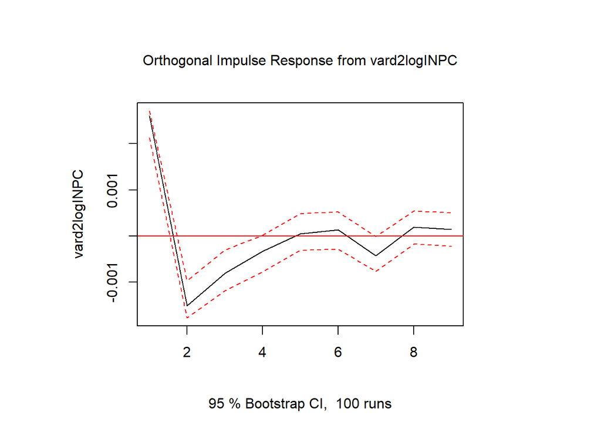

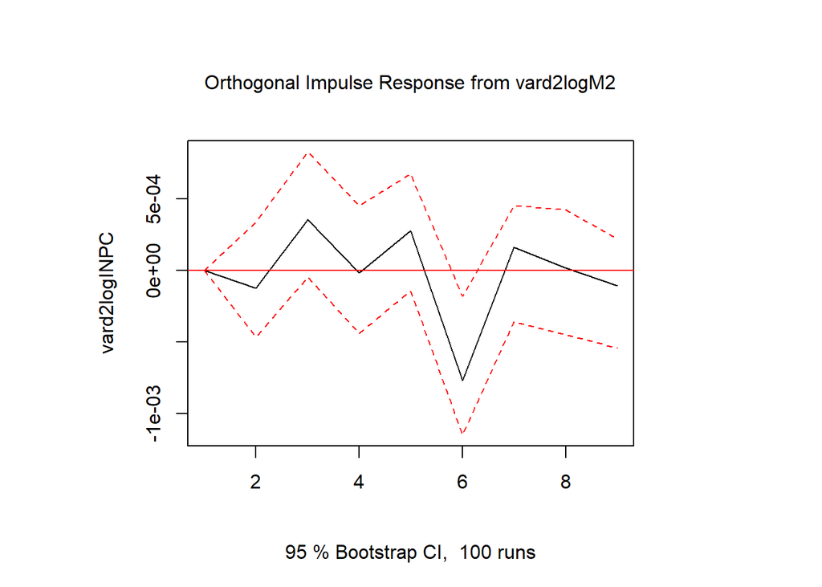

```r
plot(var1_ir)
```

## DESCOMPOSICÓN DE LA VARIANZA

Uno de los objetivos de este tipo de modelos es la predicción o el pronostico del mismo, por lo que, para lograr esto podemos recurrir a la descomposición de la varianza. Utilizamos el siguiente código para obtener el análisis de la descomposición de la varianza ante una innovación por parte de los precios.

```r
var1_desvarINPC <- fevd(var1, n.ahead = 10) $vard2logINPC
var1_desvarINPC
```

```
##       vard2logINPC  vard2logM2
##  [1,]    1.0000000 0.000000000
##  [2,]    0.9982785 0.001721544
##  [3,]    0.9859404 0.014059608
##  [4,]    0.9860592 0.013940845
##  [5,]    0.9785521 0.021447947
##  [6,]    0.9242227 0.075777295
##  [7,]    0.9232963 0.076703747
##  [8,]    0.9235475 0.076452494
##  [9,]    0.9226774 0.077322562
## [10,]    0.9076032 0.092396836
```

Ahora procedemos a obtener la descomposición de la varianza ante una innovación por parte de la oferta monetaria M2.

```r
var1_desvarM2 <- fevd(var1, n.ahead = 10) $vard2logM2
var1_desvarM2
```

```
##       vard2logINPC vard2logM2
##  [1,]  0.001411324  0.9985887
##  [2,]  0.005291278  0.9947087
##  [3,]  0.010992281  0.9890077
##  [4,]  0.011325678  0.9886743
##  [5,]  0.012997031  0.9870030
##  [6,]  0.013030382  0.9869696
##  [7,]  0.017325078  0.9826749
##  [8,]  0.039735146  0.9602649
##  [9,]  0.060969257  0.9390307
## [10,]  0.062301198  0.9376988
```